# Sophie's Python Project - (Prosper Loan)

## Introduction

1. Dataset Description:

This loan dataset contains information about various loans issued by Prosperloan and details of loan applications. It will be used to analyze lending risk, predict loan defaults and understand borrower behavior. The dataset comprises 113,937 entries and 81 columns, offering detailed information across various features. Each row represents a unique data point, providing a comprehensive view of the dataset. The 81 columns capture different attributes. Overall, it’s a large dataset with rich data for insights.

```python
import numpy as np
import pandas as pd
import matplotlib.pyplot as plt
import seaborn as sns
import plotly as py
```

```python
df = pd.read_csv('Prosper_Loan.csv')
```

```python
df
```

|  | ListingKey | ListingNumber | ListingCreationDate | CreditGrade | Term | LoanStatus | ClosedDate | BorrowerAPR | BorrowerRate | LenderYield | ... | LP_ServiceFees | LP_CollectionFees | LP_GrossPrincipalLoss | LP_NetPrincipalLoss | LP_NonPrincipalRecoverypayments | PercentFunded | Recommendations | InvestmentFromFriendsCount | InvestmentFromFriendsAmount | Investors |
| --- | --- | --- | --- | --- | --- | --- | --- | --- | --- | --- | --- | --- | --- | --- | --- | --- | --- | --- | --- | --- | --- |
| 0 | 1021339766868145413AB3B | 193129 | 09:29.3 | C | 36 | Completed | 14/08/2009 00:00 | 0.16516 | 0.1580 | 0.1380 | ... | -133.18 | 0.0 | 0.0 | 0.0 | 0.0 | 1.0 | 0 | 0 | 0.0 | 258 |
| 1 | 10273602499503308B223C1 | 1209647 | 28:07.9 | NaN | 36 | Current | NaN | 0.12016 | 0.0920 | 0.0820 | ... | 0.00 | 0.0 | 0.0 | 0.0 | 0.0 | 1.0 | 0 | 0 | 0.0 | 1 |
| 2 | 0EE9337825851032864889A | 81716 | 00:47.1 | HR | 36 | Completed | 17/12/2009 00:00 | 0.28269 | 0.2750 | 0.2400 | ... | -24.20 | 0.0 | 0.0 | 0.0 | 0.0 | 1.0 | 0 | 0 | 0.0 | 41 |
| 3 | 0EF5356002482715299901A | 658116 | 02:35.0 | NaN | 36 | Current | NaN | 0.12528 | 0.0974 | 0.0874 | ... | -108.01 | 0.0 | 0.0 | 0.0 | 0.0 | 1.0 | 0 | 0 | 0.0 | 158 |
| 4 | 0F023589499656230C5E3E2 | 909464 | 38:39.1 | NaN | 36 | Current | NaN | 0.24614 | 0.2085 | 0.1985 | ... | -60.27 | 0.0 | 0.0 | 0.0 | 0.0 | 1.0 | 0 | 0 | 0.0 | 20 |
| ... | ... | ... | ... | ... | ... | ... | ... | ... | ... | ... | ... | ... | ... | ... | ... | ... | ... | ... | ... | ... | ... |
| 113932 | E6D9357655724827169606C | 753087 | 55:02.7 | NaN | 36 | Current | NaN | 0.22354 | 0.1864 | 0.1764 | ... | -75.58 | 0.0 | 0.0 | 0.0 | 0.0 | 1.0 | 0 | 0 | 0.0 | 1 |
| 113933 | E6DB353036033497292EE43 | 537216 | 42:55.3 | NaN | 36 | FinalPaymentInProgress | NaN | 0.13220 | 0.1110 | 0.1010 | ... | -30.05 | 0.0 | 0.0 | 0.0 | 0.0 | 1.0 | 0 | 0 | 0.0 | 22 |
| 113934 | E6E13596170052029692BB1 | 1069178 | 49:12.7 | NaN | 60 | Current | NaN | 0.23984 | 0.2150 | 0.2050 | ... | -16.91 | 0.0 | 0.0 | 0.0 | 0.0 | 1.0 | 0 | 0 | 0.0 | 119 |
| 113935 | E6EB3531504622671970D9E | 539056 | 18:26.6 | NaN | 60 | Completed | 13/08/2013 00:00 | 0.28408 | 0.2605 | 0.2505 | ... | -235.05 | 0.0 | 0.0 | 0.0 | 0.0 | 1.0 | 0 | 0 | 0.0 | 274 |
| 113936 | E6ED3600409833199F711B7 | 1140093 | 27:37.7 | NaN | 36 | Current | NaN | 0.13189 | 0.1039 | 0.0939 | ... | -1.70 | 0.0 | 0.0 | 0.0 | 0.0 | 1.0 | 0 | 0 | 0.0 | 1 |

113937 rows × 81 columns

```python
df.info()
```

```
<class 'pandas.core.frame.DataFrame'>
RangeIndex: 113937 entries, 0 to 113936
Data columns (total 81 columns):
 #   Column                               Non-Null Count   Dtype
---  ------                               --------------   -----
 0   ListingKey                           113937 non-null  object
 1   ListingNumber                        113937 non-null  int64
 2   ListingCreationDate                  113937 non-null  object
 3   CreditGrade                          28953 non-null   object
 4   Term                                 113937 non-null  int64
 5   LoanStatus                           113937 non-null  object
 6   ClosedDate                           55089 non-null   object
 7   BorrowerAPR                          113912 non-null  float64
 8   BorrowerRate                         113937 non-null  float64
 9   LenderYield                          113937 non-null  float64
```

[output cut: 73 more lines]

```python
df.describe()
```

|  | ListingNumber | Term | BorrowerAPR | BorrowerRate | LenderYield | EstimatedEffectiveYield | EstimatedLoss | EstimatedReturn | ProsperRating (numeric) | ProsperScore | ... | LP_ServiceFees | LP_CollectionFees | LP_GrossPrincipalLoss | LP_NetPrincipalLoss | LP_NonPrincipalRecoverypayments | PercentFunded | Recommendations | InvestmentFromFriendsCount | InvestmentFromFriendsAmount | Investors |
| --- | --- | --- | --- | --- | --- | --- | --- | --- | --- | --- | --- | --- | --- | --- | --- | --- | --- | --- | --- | --- | --- |
| count | 1.139370e+05 | 113937.000000 | 113912.000000 | 113937.000000 | 113937.000000 | 84853.000000 | 84853.000000 | 84853.000000 | 84853.000000 | 84853.000000 | ... | 113937.000000 | 113937.000000 | 113937.000000 | 113937.000000 | 113937.000000 | 113937.000000 | 113937.000000 | 113937.000000 | 113937.000000 | 113937.000000 |
| mean | 6.278857e+05 | 40.830248 | 0.218828 | 0.192764 | 0.182701 | 0.168661 | 0.080306 | 0.096068 | 4.072243 | 5.950067 | ... | -54.725641 | -14.242698 | 700.446342 | 681.420499 | 25.142686 | 0.998584 | 0.048027 | 0.023460 | 16.550751 | 80.475228 |
| std | 3.280762e+05 | 10.436212 | 0.080364 | 0.074818 | 0.074516 | 0.068467 | 0.046764 | 0.030403 | 1.673227 | 2.376501 | ... | 60.675425 | 109.232758 | 2388.513831 | 2357.167068 | 275.657937 | 0.017919 | 0.332353 | 0.232412 | 294.545422 | 103.239020 |
| min | 4.000000e+00 | 12.000000 | 0.006530 | 0.000000 | -0.010000 | -0.182700 | 0.004900 | -0.182700 | 1.000000 | 1.000000 | ... | -664.870000 | -9274.750000 | -94.200000 | -954.550000 | 0.000000 | 0.700000 | 0.000000 | 0.000000 | 0.000000 | 1.000000 |
| 25% | 4.009190e+05 | 36.000000 | 0.156290 | 0.134000 | 0.124200 | 0.115670 | 0.042400 | 0.074080 | 3.000000 | 4.000000 | ... | -73.180000 | 0.000000 | 0.000000 | 0.000000 | 0.000000 | 1.000000 | 0.000000 | 0.000000 | 0.000000 | 2.000000 |
| 50% | 6.005540e+05 | 36.000000 | 0.209760 | 0.184000 | 0.173000 | 0.161500 | 0.072400 | 0.091700 | 4.000000 | 6.000000 | ... | -34.440000 | 0.000000 | 0.000000 | 0.000000 | 0.000000 | 1.000000 | 0.000000 | 0.000000 | 0.000000 | 44.000000 |
| 75% | 8.926340e+05 | 36.000000 | 0.283810 | 0.250000 | 0.240000 | 0.224300 | 0.112000 | 0.116600 | 5.000000 | 8.000000 | ... | -13.920000 | 0.000000 | 0.000000 | 0.000000 | 0.000000 | 1.000000 | 0.000000 | 0.000000 | 0.000000 | 115.000000 |
| max | 1.255725e+06 | 60.000000 | 0.512290 | 0.497500 | 0.492500 | 0.319900 | 0.366000 | 0.283700 | 7.000000 | 11.000000 | ... | 32.060000 | 0.000000 | 25000.000000 | 25000.000000 | 21117.900000 | 1.012500 | 39.000000 | 33.000000 | 25000.000000 | 1189.000000 |

8 rows × 61 columns

```python
df.shape
```

```
(113937, 81)
```

```python
df.columns=df.columns.str.lower()
```

```python
df.head(1)
```

|  | listingkey | listingnumber | listingcreationdate | creditgrade | term | loanstatus | closeddate | borrowerapr | borrowerrate | lenderyield | ... | lp_servicefees | lp_collectionfees | lp_grossprincipalloss | lp_netprincipalloss | lp_nonprincipalrecoverypayments | percentfunded | recommendations | investmentfromfriendscount | investmentfromfriendsamount | investors |
| --- | --- | --- | --- | --- | --- | --- | --- | --- | --- | --- | --- | --- | --- | --- | --- | --- | --- | --- | --- | --- | --- |
| 0 | 1021339766868145413AB3B | 193129 | 09:29.3 | C | 36 | Completed | 14/08/2009 00:00 | 0.16516 | 0.158 | 0.138 | ... | -133.18 | 0.0 | 0.0 | 0.0 | 0.0 | 1.0 | 0 | 0 | 0.0 | 258 |

1 rows × 81 columns

```python
df.isnull().sum()
```

```
listingkey                         0
listingnumber                      0
listingcreationdate                0
creditgrade                    84984
term                               0
                               ...
percentfunded                      0
recommendations                    0
investmentfromfriendscount         0
investmentfromfriendsamount        0
investors                          0
Length: 81, dtype: int64
```

```python
missing_data=df.isnull().sum()
```

```python
#### Delete columns with more than 50% missing values
threshold = len(df) * 0.5
columns_to_drop = missing_data[missing_data > threshold].index
```

```python
columns_to_drop
```

```
Index(['creditgrade', 'closeddate', 'groupkey', 'totalprosperloans',
       'totalprosperpaymentsbilled', 'ontimeprosperpayments',
       'prosperpaymentslessthanonemonthlate',
       'prosperpaymentsonemonthpluslate', 'prosperprincipalborrowed',
       'prosperprincipaloutstanding', 'scorexchangeattimeoflisting',
       'loanfirstdefaultedcyclenumber'],
      dtype='object')
```

```python
#Delete the columns above
df_cleaned = df.drop(columns=columns_to_drop)
```

```python
#Fill missing values for numerical columns with the median
numerical_columns = df_cleaned.select_dtypes(include=[np.number]).columns
for col in numerical_columns:
    df_cleaned.fillna({col:df_cleaned[col].median()}, inplace=True)
```

```python
# Fill missing values for categorical columns with the mode
categorical_cols = df_cleaned.select_dtypes(include=['object']).columns
for col in categorical_cols:
    df_cleaned.fillna({col:df_cleaned[col].mode()}, inplace=True)
```

```python
# Convert date columns to datetime format
for col in df_cleaned.columns:
    if 'Date' in col or 'date' in col:
        df_cleaned[col] = pd.to_datetime(df_cleaned[col], format="%d/%m/%Y", errors='coerce')
```

```python
df_cleaned.columns
```

```
Index(['listingkey', 'listingnumber', 'listingcreationdate', 'term',
       'loanstatus', 'borrowerapr', 'borrowerrate', 'lenderyield',
       'estimatedeffectiveyield', 'estimatedloss', 'estimatedreturn',
       'prosperrating (numeric)', 'prosperrating (alpha)', 'prosperscore',
       'listingcategory (numeric)', 'borrowerstate', 'occupation',
       'employmentstatus', 'employmentstatusduration', 'isborrowerhomeowner',
       'currentlyingroup', 'datecreditpulled', 'creditscorerangelower',
       'creditscorerangeupper', 'firstrecordedcreditline',
       'currentcreditlines', 'opencreditlines', 'totalcreditlinespast7years',
       'openrevolvingaccounts', 'openrevolvingmonthlypayment',
       'inquirieslast6months', 'totalinquiries', 'currentdelinquencies',
       'amountdelinquent', 'delinquencieslast7years',
       'publicrecordslast10years', 'publicrecordslast12months',
       'revolvingcreditbalance', 'bankcardutilization',
       'availablebankcardcredit', 'totaltrades',
       'tradesneverdelinquent (percentage)', 'tradesopenedlast6months',
       'debttoincomeratio', 'incomerange', 'incomeverifiable',
       'statedmonthlyincome', 'loankey', 'loancurrentdaysdelinquent',
       'loanmonthssinceorigination', 'loannumber', 'loanoriginalamount',
       'loanoriginationdate', 'loanoriginationquarter', 'memberkey',
       'monthlyloanpayment', 'lp_customerpayments',
       'lp_customerprincipalpayments', 'lp_interestandfees', 'lp_servicefees',
       'lp_collectionfees', 'lp_grossprincipalloss', 'lp_netprincipalloss',
       'lp_nonprincipalrecoverypayments', 'percentfunded', 'recommendations',
       'investmentfromfriendscount', 'investmentfromfriendsamount',
       'investors'],
      dtype='object')
```

### What is the structure of your dataset?

> This loan dataset contains information about various loans issued by ProsperLoan. The structure of ths dataset includes the following info/types of columns:Loan information, borrower information,Loan status , repayment information.

### What is/are the main feature(s) of interest in your dataset?

> The main features of interest in my loan dataset are as follows;
1. Loan_Status: This is the primary feature of interest, especially when assessing loan performance. We need to know whether loans are approved, rejected, paid off, or defaulted.
2. Loan_Amount: The principal amount borrowed is crucial for understanding the scale of the loan, its risk, and its impact on the lender's portfolio.
3. Interest_Rate: This determines the cost of borrowing for the borrower and the potential revenue for the lender. It is key in assessing profitability and risk.
4. Borrower Credit Score

Credit_Score: A critical predictor of loan repayment behavior. Higher credit scores generally indicate lower risk of default. 5. Loan Term Loan_Term: The duration of the loan affects the monthly payment amount and the overall interest paid over time. It’s important for understanding repayment schedules and loan affordability. 6. Repayment Information Monthly_Payment: This indicates the borrower's monthly financial obligation and can be used to assess affordability and the likelihood of default. Remaining_Balance: Helps in tracking the loan’s lifecycle and understanding how much of the loan is still outstanding. 7. Borrower Income Borrower_Income: Used to assess the borrower’s ability to repay the loan. Higher income typically suggests a lower risk of default.

### What features in the dataset do you think will help support your investigation into your feature(s) of interest?

The three most important features in my loan dataset, particularly for assessing risk and making lending decisions, are:

Loan Status: Indicates the current state of the loan (approved, defaulted, paid off). It’s crucial for evaluating loan performance and understanding repayment behavior.

Credit Score: A key predictor of a borrower’s likelihood to repay the loan. It directly impacts risk assessment and the decision to approve or deny a loan.

Loan Amount: The principal borrowed amount, which determines the potential risk and financial exposure for the lender.

## Univariate Exploration

### 1. Loan status

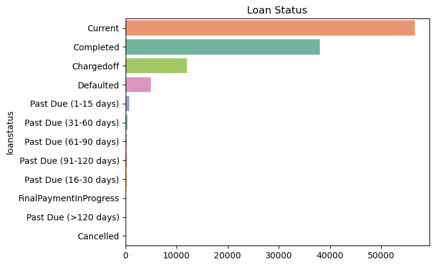

```python
plt.figure()
sns.countplot(data=df_cleaned, y='loanstatus', order=df_cleaned['loanstatus'].value_counts().index, hue ='loanstatus', palette ='Set2')
plt.title('Loan Status')
plt.xlabel(' ')
plt.show()
```

### 2. Loan Amount

Kdeplot to visualize the range and distribution of loan amounts.

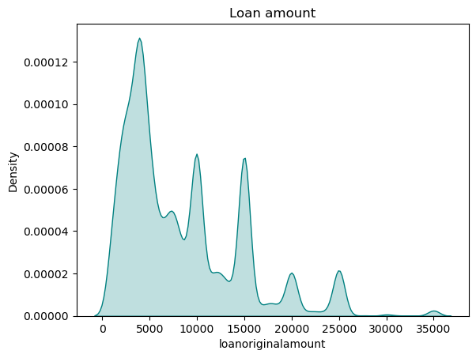

```python
plt.figure()
sns.kdeplot(df_cleaned['loanoriginalamount'], color ='teal',fill= True)
plt.title('Loan amount');
```

### 3. Credit score range( upper and lower)

Combined kde plot with hue parameter to analyze the creditworthiness of borrowers.

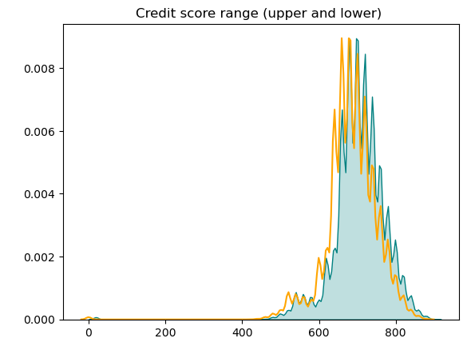

```python
plt.figure()
sns.kdeplot(df_cleaned['creditscorerangeupper'],color ='teal',fill= True)
sns.kdeplot(df_cleaned['creditscorerangelower'],color ='orange')
plt.title('Credit score range (upper and lower) ')
plt.xlabel(' ')
plt.ylabel(' ')
plt.show()
```

### 4.Borrower's annual percentage rate %

Distribution to see the spread of interest rates across loans.

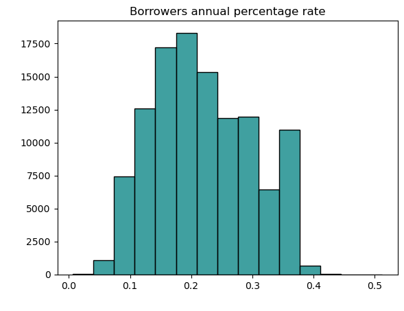

```python
plt.figure()
sns.histplot(df_cleaned['borrowerapr'], bins=15, color ='teal')
plt.title('Borrowers annual percentage rate')
plt.xlabel(' ')
plt.ylabel(' ')
plt.show()
```

### 5.Employment Status

Frequency distribution to assess the employment background of borrowers.

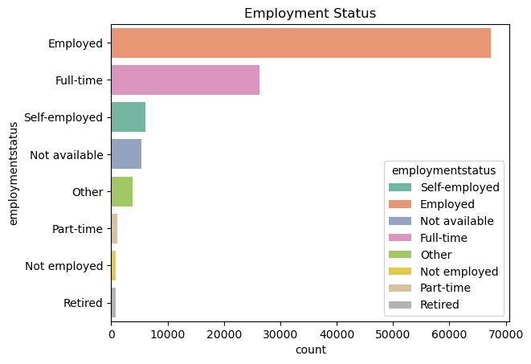

```python
plt.figure()
sns.countplot(data=df_cleaned, y='employmentstatus', order=df_cleaned['employmentstatus'].value_counts().index, hue ='employmentstatus', palette ='Set2')
plt.title('Employment Status')
plt.show()
```

### Income Range

Used to assess the borrower’s ability to repay the loan. Higher income typically suggests a lower risk of default.

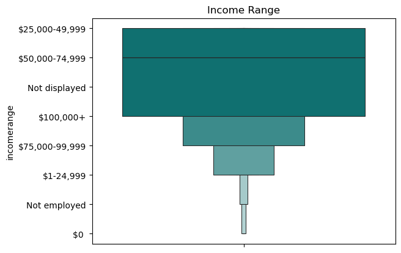

```python
plt.figure()
sns.boxenplot(data=df_cleaned, y = 'incomerange', color ='Teal')
plt.title('Income Range');
```

### 1. Loan Status vs. Employment Status

[figure not shown]

```python
plt.figure(figsize=(18, 9))
sns.barplot(data= df_cleaned, x= 'loanstatus', y= 'employmentstatus', hue="loanstatus", palette ='Set2',errorbar=None)
plt.title('Loan status vs Employment status')
plt.xlabel(' ')
plt.ylabel('')
plt.show();
```

### 2. Loan Status vs. Loan term

Explore how different loan terms impact loan performance.

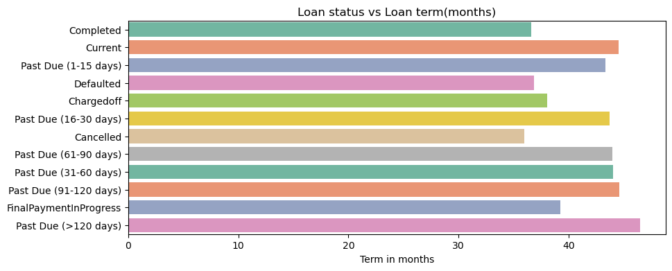

```python
plt.figure(figsize=(10, 4))
sns.barplot(data= df_cleaned, x= 'term', y= 'loanstatus', hue="loanstatus", palette ='Set2',errorbar=None)
plt.title('Loan status vs Loan term(months)')
plt.xlabel('Term in months')
plt.ylabel('')
plt.show();
```

### 3. Loanstatus vs. credit score

boxen plot to explore the relationship between credit scores and loan outcomes.

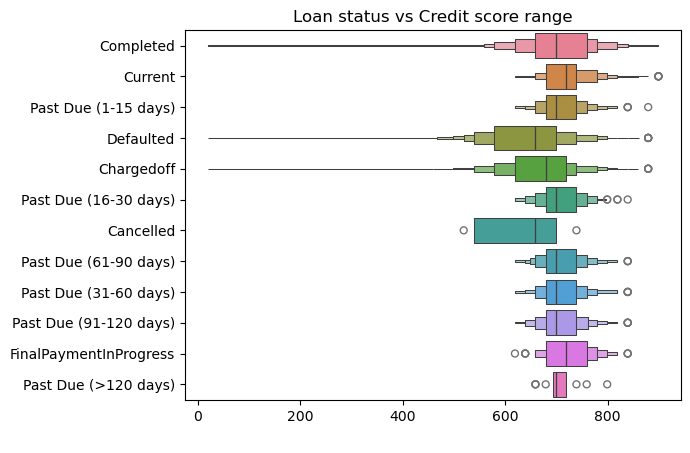

```python
plt.figure()
sns.boxenplot(data=df_cleaned, x= 'creditscorerangeupper', y='loanstatus', hue="loanstatus")
plt.title('Loan status vs Credit score range')
plt.xlabel(' ')
plt.ylabel('')
plt.show()
```

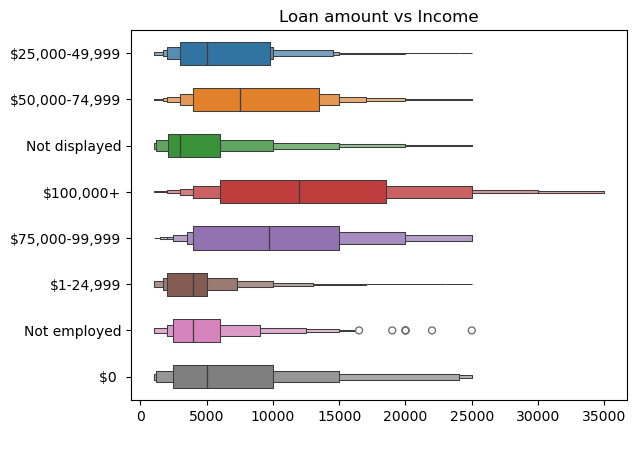

```python
plt.figure()
sns.boxenplot(data=df_cleaned, x= 'loanoriginalamount', y='incomerange',width=.5,hue="incomerange" )
plt.title('Loan amount vs Income')
plt.xlabel(' ')
plt.ylabel('')
plt.show()
```

### 5. Loan Original Amount vs. Borrower APR

Understand how loan amounts influence the interest rate offered.

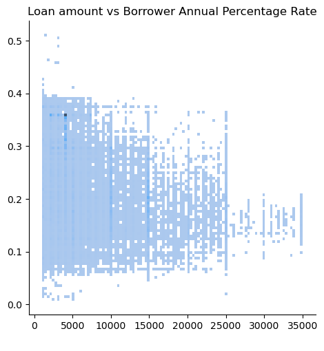

```python
plt.figure(figsize=(15, 5))
sns.displot(data=df_cleaned, x= 'loanoriginalamount', y='borrowerapr' )
plt.title('Loan amount vs Borrower Annual Percentage Rate')
plt.xlabel(' ')
plt.ylabel('')
plt.show()
```

```
-Loan Status Distribution: The majority of loans are either current or completed, with fewer loans in default or other statuses.
-Loan Amount Distribution: Loan amounts vary widely, with a significant concentration around certain values, indicating common borrowing ranges.
-Credit Score Range: Borrowers’ credit scores show a broad distribution, with distinct peaks for upper and lower ranges, reflecting varied creditworthiness.
-Employment Status: Most borrowers are employed, with fewer in other employment categories, highlighting the importance of stable income for loan approval.

These insights help in understanding borrower behavior and loan performance.
```

Conclusion The analysis involved using various bivariate and univariate charts to visualize these relationships, providing insights into lending risks and borrower behavior.The data cleaning and transformation process played a vital role in ensuring the dataset was ready for analysis. The exploration provided insights into key features and their relationships, aiding in risk assessment and lending decisions.